# EDA of Diabetes Data Set

yung chou

December 5, 2018

## Data Set

- Diabetes 130-US hospitals for years 1999-2008 Data Set, https://archive.ics.uci.edu/ml/datasets/diabetes+130-us+hospitals+for+years+1999-2008
- Reference: Feature description, https://www.hindawi.com/journals/bmri/2014/781670/

```
## The data set has initially  101766  observations with  50  variables.
```

```
## 'data.frame':    101766 obs. of  50 variables:
##  $ encounter_id            : int  2278392 149190 64410 500364 16680 35754 55842 63768 12522 15738 ...
##  $ patient_nbr             : int  8222157 55629189 86047875 82442376 42519267 82637451 84259809 114882984 48330783 63555939 ...
##  $ race                    : Factor w/ 6 levels "?","AfricanAmerican",..: 4 4 2 4 4 4 4 4 4 4 ...
##  $ gender                  : Factor w/ 3 levels "Female","Male",..: 1 1 1 2 2 2 2 2 1 1 ...
##  $ age                     : Factor w/ 10 levels "[0-10)","[10-20)",..: 1 2 3 4 5 6 7 8 9 10 ...
##  $ weight                  : Factor w/ 10 levels "?","[0-25)","[100-125)",..: 1 1 1 1 1 1 1 1 1 1 ...
##  $ admission_type_id       : int  6 1 1 1 1 2 3 1 2 3 ...
##  $ discharge_disposition_id: int  25 1 1 1 1 1 1 1 1 3 ...
##  $ admission_source_id     : int  1 7 7 7 7 2 2 7 4 4 ...
##  $ time_in_hospital        : int  1 3 2 2 1 3 4 5 13 12 ...
##  $ payer_code              : Factor w/ 18 levels "?","BC","CH",..: 1 1 1 1 1 1 1 1 1 1 ...
##  $ medical_specialty       : Factor w/ 73 levels "?","AllergyandImmunology",..: 39 1 1 1 1 1 1 1 1 20 ...
##  $ num_lab_procedures      : int  41 59 11 44 51 31 70 73 68 33 ...
##  $ num_procedures          : int  0 0 5 1 0 6 1 0 2 3 ...
```

[output cut: 36 more lines]

- Dropping the ID field, encounter_id

```
## Removed encounter_id. The data set now has  49  variables.
```

## Missingness

In the data set, there were variables with ‘?’ not documented as a valid code. Which apparently were missing values, and therefore here replaced with NA.

```
## Values stored as "?" =  192849
```

```
## Replacing  192849  values stored as "?" with NA.
```

```
## Values stored as "?" =  NA
```

```
## Total NA count =  192849
```

- Inital view of missingness revealed disportional amount of data were missing in **weight**, **medical_speciality**, and **payer_code**.

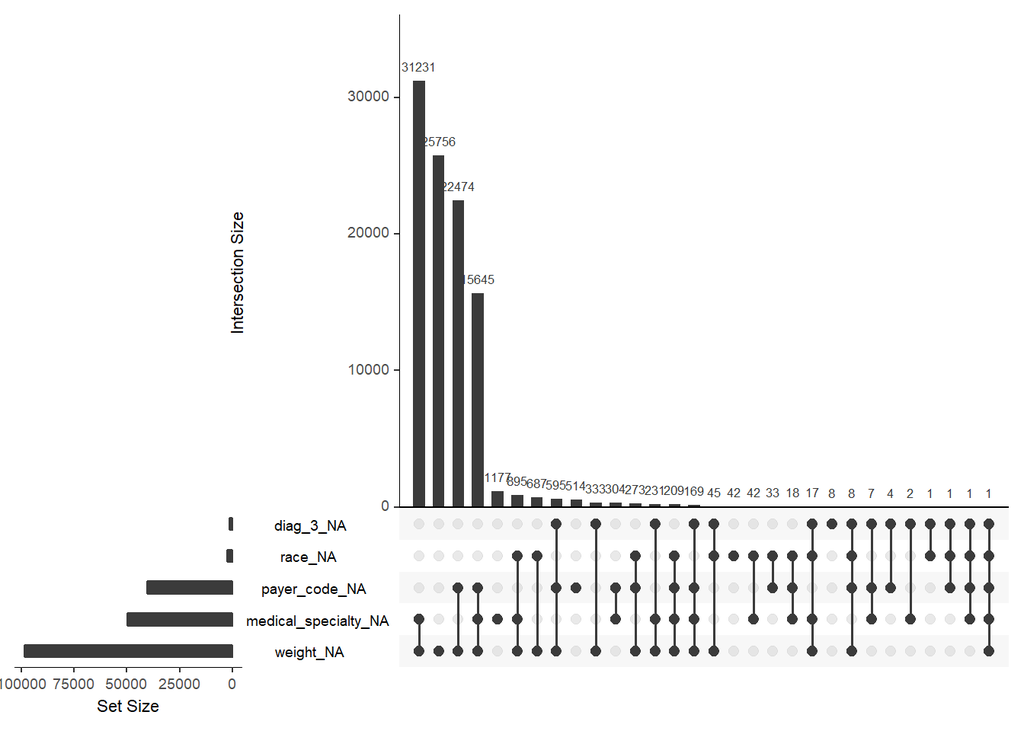

- Further examination confirmed there was no missing vlues of numeric variables.

```
## 0  missing values of all numberic variables
```

```
## 192849  missing valuesof all factor variables
```

- The percentage of values missing for those factor variables with missing values are as the following. And a threshold of missingness is set for 30% and the three abovementioned variables are removed from consideration at this time.

```
##              race            weight        payer_code medical_specialty
##              2.23             96.86             39.56             49.08
##            diag_1            diag_2            diag_3
##              0.02              0.35              1.40
```

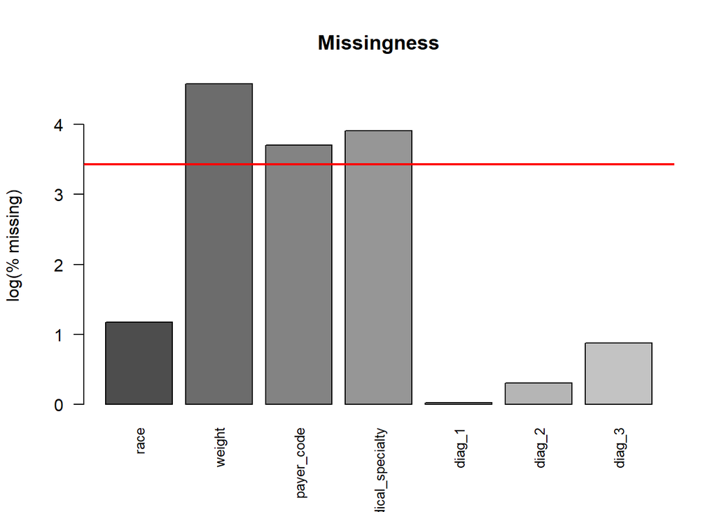

```
## At this time, the data set has  101766  observations with  46  variables.
```

### Zero-Variance Variables

```
## caret reports  18 near-nero variables as the following:
```

```
##  [1] "max_glu_serum"            "repaglinide"
##  [3] "nateglinide"              "chlorpropamide"
##  [5] "glimepiride"              "acetohexamide"
##  [7] "tolbutamide"              "acarbose"
##  [9] "miglitol"                 "troglitazone"
## [11] "tolazamide"               "examide"
## [13] "citoglipton"              "glyburide.metformin"
## [15] "glipizide.metformin"      "glimepiride.pioglitazone"
## [17] "metformin.rosiglitazone"  "metformin.pioglitazone"
```

```
## The listed,  18  near-zero variables have been removed.
##
##  At this time, the data set has  101766  observations with  28  variables remaining.
```

## Multiple Encounters of a Patient

The data set contained multiple rows with the same patient_nbr, i.e. a paitnet number. It is unclear if these encounters were related or independent, whiel the former may introduce bias since some encounters of a patient then become correlated. The strategy here is to keep one and only one encounter with the maximum time_in_hospital which is assumed to characteristic for readmission and provide most variance at the same time.

```
## patient_nbr with multiple encounters =  30248
```

```
## Before eliminating multiple encounters of a patient, total  101766  observations
```

```
## After eliminating multiple encounters of a patient, total  71518  observations
```

```
## Multiple encounters of a patient now =  0
```

```
## Removed patient_nbr which is an ID field and no longer needed.
##  At this time, the data set has  71518  observations with  27  variables.
```

## Categorical Variables

- Now consolidate the levels of a categorical variable, as applicable.
- For those not to be later dummified, convert them into numberic.

### gender and age

```
## "gender" is now  factor  with the levels:  Femals Male
```

```
## Considering those older than 60 are twice more likely to be readmitted.
```

```
## "age" is now  numeric  with the unique values:  1.5 1 2
##  where age<60 is assigned as 1, 60<=age<80 1.5, and age>80 as 2
```

### admission_type_id, admission_source_id, and discharge_disposition_id

```
## "admission_type_id" is now  factor  with levels:  k u
##  where u: unknow, k: known
```

```
## "admission_source_id" is now  factor  with levels:  b o r t u
##  where r: referral, t: transfer, u: unknown, o: other, b: birth
```

- Removing disposition code associated with ‘Expired’ since not relevant to readmission

```
## Before removing "discharge_disposition_id" of 11,19,20,21,
## therer were  71518  observations with unique ids:
##  1 3 25 6 2 11 5 8 13 4 18 17 22 14 23 7 28 27 15 10 16 9 20 24 12 19
```

```
## After removing "discharge_disposition_id" of 11,19,20,21,
## therer were  70245  observations with unique ids:
##  1 3 25 6 2 5 8 13 4 18 17 22 14 23 7 28 27 15 10 16 9 24 12
```

```
## "discharge_disposition_id)" is now  factor  with levels:  d h o u
##  where d: discharge, h: hospice, u: unknown, o: other
```

### Converting diag_1, diag_2, and diag_3 into 9 Categories

Each of these three factor variables has 700+ levels. Per Table 2 of [Impact of HbA1c Measurement on Hospital Readmission Rates: Analysis of 70,000 Clinical Database Patient Records](https://www.hindawi.com/journals/bmri/2014/781670/tab2/), they are converted into 9 categories as below.

### diag_1

```
## *** diag_1 with  717  levels
```

```
## *** diag_1 is now converted to  9  levels as the following:
##  Circulatory Diabetes Digestive Genitourinary Injury Musculoskeletal Neoplasms Other Respiratory
```

### diag_2

```
## *** diag_2 with  749  levels
```

```
## *** diag_2 is now converted to  9  levels as the following:
##  Circulatory Diabetes Digestive Genitourinary Injury Musculoskeletal Neoplasms Other Respiratory
```

### diag_3

```
## *** diag_3 with  790  levels
```

```
## *** diag_3 is now converted to  9  levels as the following:
##  Circulatory Diabetes Digestive Genitourinary Injury Musculoskeletal Neoplasms Other Respiratory
```

### Response Variable

The response variable, readmitted, originally had three levels: <30, >30, and NO. For classification, consolidate it to just two levels, yes and no.

```
## "readmitted" levels:  <30 >30 NO
```

```
## "readmitted" is now a  factor  with levels:  no yes
```

```
## At this time, the data set has  70245  observations with  27  variables.
```

## Numeric Variables

In addition to scale the numeric variables, their values also must be examined and adjusted, as applicable. For instance, regaridng time_in_hospital, do those who stayed for 14 days more likely to be readmitted within 30 days than those stayed for 7 days? Does a patient have 28 lab procedures ordered be less propable on readmission than who with 43? These numberic variables must be adjusted and scale to a meaningful and reasonable level to supoort a model for predicting readmission.

- time_in_hospital
- num_lab_procedures
- num_medications
- num_procedures

## Scaling

```
## 'data.frame':    70245 obs. of  1 variable:
##  $ readmitted: Factor w/ 2 levels "no","yes": 1 2 1 1 1 1 2 1 1 1 ...
## "readmitted" has been removed.
```

```
## 'data.frame':    70245 obs. of  26 variables:
##  $ race                    : Factor w/ 6 levels "?","AfricanAmerican",..: 4 4 4 4 4 4 4 4 4 4 ...
##  $ gender                  : Factor w/ 2 levels "Femals","Male": 1 2 2 1 1 1 1 1 1 1 ...
##  $ age                     : num  1.5 1.5 1 2 1.5 1.5 1.5 1.5 1 2 ...
##  $ admission_type_id       : Factor w/ 2 levels "k","u": 1 1 2 2 2 2 2 1 2 2 ...
##  $ discharge_disposition_id: Factor w/ 4 levels "d","h","o","u": 1 1 4 1 4 4 4 1 1 4 ...
##  $ admission_source_id     : Factor w/ 5 levels "b","o","r","t",..: 3 2 3 3 2 2 3 4 3 2 ...
##  $ time_in_hospital        : int  14 14 14 14 14 14 14 14 14 14 ...
##  $ num_lab_procedures      : int  28 78 41 44 71 71 61 78 43 76 ...
##  $ num_procedures          : int  3 1 1 2 3 1 6 6 0 4 ...
##  $ num_medications         : int  28 19 18 12 33 32 34 43 11 28 ...
##  $ number_outpatient       : int  0 0 0 0 0 0 0 0 0 0 ...
##  $ number_emergency        : int  0 0 0 0 0 0 0 0 0 0 ...
##  $ number_inpatient        : int  0 0 0 0 0 0 0 0 0 0 ...
##  $ diag_1                  : Factor w/ 9 levels "Circulatory",..: 7 1 6 2 3 9 1 1 2 1 ...
##  $ diag_2                  : Factor w/ 9 levels "Circulatory",..: 7 2 5 2 9 1 5 1 2 1 ...
##  $ diag_3                  : Factor w/ 9 levels "Circulatory",..: 3 2 2 1 1 2 1 1 3 6 ...
##  $ number_diagnoses        : int  8 8 4 3 9 9 6 9 3 9 ...
##  $ A1Cresult               : Factor w/ 4 levels ">7",">8","None",..: 3 4 3 4 1 3 3 3 1 3 ...
##  $ metformin               : Factor w/ 4 levels "Down","No","Steady",..: 3 2 3 3 2 2 2 3 2 2 ...
##  $ glipizide               : Factor w/ 4 levels "Down","No","Steady",..: 3 2 3 4 2 2 3 3 2 2 ...
##  $ glyburide               : Factor w/ 4 levels "Down","No","Steady",..: 2 2 3 2 2 2 2 2 2 2 ...
##  $ pioglitazone            : Factor w/ 4 levels "Down","No","Steady",..: 2 2 2 2 2 2 2 2 2 2 ...
##  $ rosiglitazone           : Factor w/ 4 levels "Down","No","Steady",..: 2 2 2 2 2 2 2 2 2 2 ...
##  $ insulin                 : Factor w/ 4 levels "Down","No","Steady",..: 1 4 2 2 4 1 3 3 2 3 ...
##  $ change                  : Factor w/ 2 levels "Ch","No": 1 1 1 1 1 1 1 1 2 2 ...
##  $ diabetesMed             : Factor w/ 2 levels "No","Yes": 2 2 2 2 2 2 2 2 1 2 ...
```

```
## [1] "time_in_hospital"   "num_lab_procedures" "num_procedures"
## [4] "num_medications"    "number_outpatient"  "number_emergency"
## [7] "number_inpatient"
```

```
##  [1] "race"                     "gender"
##  [3] "age"                      "admission_type_id"
##  [5] "discharge_disposition_id" "admission_source_id"
##  [7] "diag_1"                   "diag_2"
##  [9] "diag_3"                   "number_diagnoses"
## [11] "A1Cresult"                "metformin"
## [13] "glipizide"                "glyburide"
## [15] "pioglitazone"             "rosiglitazone"
## [17] "insulin"                  "change"
## [19] "diabetesMed"
```

```
## 'data.frame':    70245 obs. of  27 variables:
##  $ time_in_hospital        : int  14 14 14 14 14 14 14 14 14 14 ...
##  $ num_lab_procedures      : int  28 78 41 44 71 71 61 78 43 76 ...
##  $ num_procedures          : int  3 1 1 2 3 1 6 6 0 4 ...
##  $ num_medications         : int  28 19 18 12 33 32 34 43 11 28 ...
##  $ number_outpatient       : int  0 0 0 0 0 0 0 0 0 0 ...
##  $ number_emergency        : int  0 0 0 0 0 0 0 0 0 0 ...
##  $ number_inpatient        : int  0 0 0 0 0 0 0 0 0 0 ...
##  $ race                    : Factor w/ 6 levels "?","AfricanAmerican",..: 4 4 4 4 4 4 4 4 4 4 ...
##  $ gender                  : Factor w/ 2 levels "Femals","Male": 1 2 2 1 1 1 1 1 1 1 ...
##  $ age                     : num  1.5 1.5 1 2 1.5 1.5 1.5 1.5 1 2 ...
##  $ admission_type_id       : Factor w/ 2 levels "k","u": 1 1 2 2 2 2 2 1 2 2 ...
##  $ discharge_disposition_id: Factor w/ 4 levels "d","h","o","u": 1 1 4 1 4 4 4 1 1 4 ...
##  $ admission_source_id     : Factor w/ 5 levels "b","o","r","t",..: 3 2 3 3 2 2 3 4 3 2 ...
##  $ diag_1                  : Factor w/ 9 levels "Circulatory",..: 7 1 6 2 3 9 1 1 2 1 ...
##  $ diag_2                  : Factor w/ 9 levels "Circulatory",..: 7 2 5 2 9 1 5 1 2 1 ...
##  $ diag_3                  : Factor w/ 9 levels "Circulatory",..: 3 2 2 1 1 2 1 1 3 6 ...
##  $ number_diagnoses        : int  8 8 4 3 9 9 6 9 3 9 ...
##  $ A1Cresult               : Factor w/ 4 levels ">7",">8","None",..: 3 4 3 4 1 3 3 3 1 3 ...
##  $ metformin               : Factor w/ 4 levels "Down","No","Steady",..: 3 2 3 3 2 2 2 3 2 2 ...
##  $ glipizide               : Factor w/ 4 levels "Down","No","Steady",..: 3 2 3 4 2 2 3 3 2 2 ...
##  $ glyburide               : Factor w/ 4 levels "Down","No","Steady",..: 2 2 3 2 2 2 2 2 2 2 ...
##  $ pioglitazone            : Factor w/ 4 levels "Down","No","Steady",..: 2 2 2 2 2 2 2 2 2 2 ...
##  $ rosiglitazone           : Factor w/ 4 levels "Down","No","Steady",..: 2 2 2 2 2 2 2 2 2 2 ...
##  $ insulin                 : Factor w/ 4 levels "Down","No","Steady",..: 1 4 2 2 4 1 3 3 2 3 ...
##  $ change                  : Factor w/ 2 levels "Ch","No": 1 1 1 1 1 1 1 1 2 2 ...
##  $ diabetesMed             : Factor w/ 2 levels "No","Yes": 2 2 2 2 2 2 2 2 1 2 ...
##  $ readmitted              : Factor w/ 2 levels "no","yes": 1 2 1 1 1 1 2 1 1 1 ...
## Data set ready for imputation at this time,
```

[output not shown]

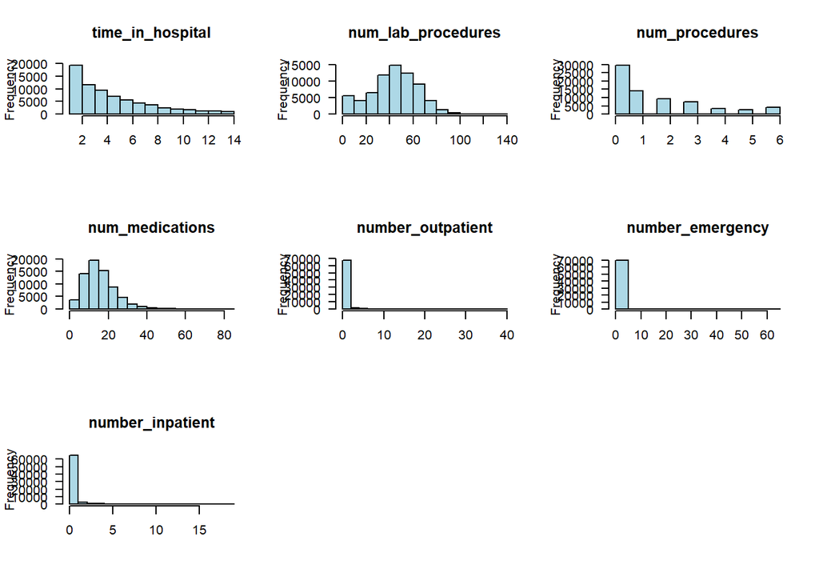

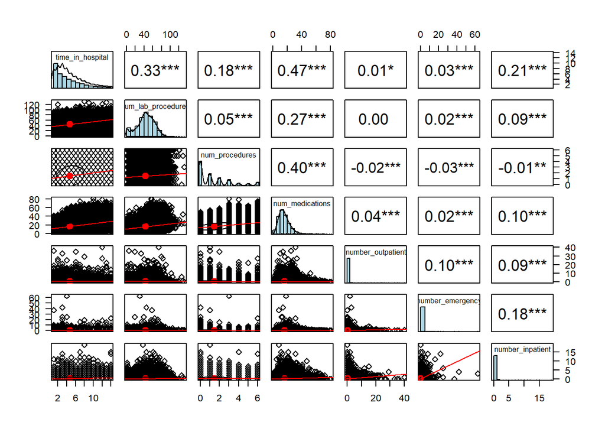